# Classification

Литвинцев И.С

29 августа 2018 г

## Задание 13.

Using the Boston data set, fit classification models in order to predict whether a given suburb has a crime rate above or below the median. Explore logistic regression, LDA, and KNN models using various subsets of the predictors. Describe your findings.

Используя Бостонский набор данных, обучите модели классификации, чтобы предсказать, имеет ли данный пригород уровень преступности выше или ниже медианы. Исследуйте модели логистической регрессии, LDA и KNN, используя различные подмножества предикторов. Опишите свои выводы

1. crim - уровень преступности на душу населения города.
2. zn - доля жилых земель, зонированных на земельные участки площадью более 25 000 кв. футов.
3. indus - доля нерыночных (розничных) акров в городе.
4. chas - фиктивная переменная реки Чарльз (= 1, Если тракт граничит с рекой; 0 В противном случае).
5. nox - концентрация оксидов азота (частей на 10 миллионов).
6. rm - среднее количество комнат в жилом помещении.
7. age - доля жилых единиц, построенных до 1940 года.
8. dis - средневзвешенное расстояние до пяти Бостонских центров занятости.
9. rad - индекс доступности радиальных магистралей.
10. tax - полная стоимость налога на имущество за $10000
11. ptratio - соотношение учеников и учителей по городу.
12. black - 1000(Bk - 0,63)^2, где Bk - доля чернокожих по городу.
13. lstat - более низкий статус населения (в процентах).
14. medv - медианная стоимость домов, занятых владельцами в $1000.

```r
library(MASS)
library(knitr)
head(Boston)
```

```
##      crim zn indus chas   nox    rm  age    dis rad tax ptratio  black
## 1 0.00632 18  2.31    0 0.538 6.575 65.2 4.0900   1 296    15.3 396.90
## 2 0.02731  0  7.07    0 0.469 6.421 78.9 4.9671   2 242    17.8 396.90
## 3 0.02729  0  7.07    0 0.469 7.185 61.1 4.9671   2 242    17.8 392.83
## 4 0.03237  0  2.18    0 0.458 6.998 45.8 6.0622   3 222    18.7 394.63
## 5 0.06905  0  2.18    0 0.458 7.147 54.2 6.0622   3 222    18.7 396.90
## 6 0.02985  0  2.18    0 0.458 6.430 58.7 6.0622   3 222    18.7 394.12
##   lstat medv
## 1  4.98 24.0
## 2  9.14 21.6
## 3  4.03 34.7
## 4  2.94 33.4
## 5  5.33 36.2
## 6  5.21 28.7
```

```r
data <- Boston

names(data)
```

```
##  [1] "crim"    "zn"      "indus"   "chas"    "nox"     "rm"      "age"
##  [8] "dis"     "rad"     "tax"     "ptratio" "black"   "lstat"   "medv"
```

Найдем медианный уровень преступности и на его основе определим классы. Таким образом, что TRUE будет означать пригород с уровнем преступности выше медианного, а FALSE - ниже.

```r
m <- median(data$crim)
data$crim.class <- data$crim > m
kable(head(data))
```

| crim | zn | indus | chas | nox | rm | age | dis | rad | tax | ptratio | black | lstat | medv | crim.class |
| --- | --- | --- | --- | --- | --- | --- | --- | --- | --- | --- | --- | --- | --- | --- |
| 0.00632 | 18 | 2.31 | 0 | 0.538 | 6.575 | 65.2 | 4.0900 | 1 | 296 | 15.3 | 396.90 | 4.98 | 24.0 | FALSE |
| 0.02731 | 0 | 7.07 | 0 | 0.469 | 6.421 | 78.9 | 4.9671 | 2 | 242 | 17.8 | 396.90 | 9.14 | 21.6 | FALSE |
| 0.02729 | 0 | 7.07 | 0 | 0.469 | 7.185 | 61.1 | 4.9671 | 2 | 242 | 17.8 | 392.83 | 4.03 | 34.7 | FALSE |
| 0.03237 | 0 | 2.18 | 0 | 0.458 | 6.998 | 45.8 | 6.0622 | 3 | 222 | 18.7 | 394.63 | 2.94 | 33.4 | FALSE |
| 0.06905 | 0 | 2.18 | 0 | 0.458 | 7.147 | 54.2 | 6.0622 | 3 | 222 | 18.7 | 396.90 | 5.33 | 36.2 | FALSE |
| 0.02985 | 0 | 2.18 | 0 | 0.458 | 6.430 | 58.7 | 6.0622 | 3 | 222 | 18.7 | 394.12 | 5.21 | 28.7 | FALSE |

```r
attach(data)
```

Разделим случайным образом данные на обучающую и тестовую выборки.

```r
n <- length(crim.class)
set.seed(1)
rand.ind <- sort(sample(1:n, size=406))
train <- rep(FALSE, n)
train[rand.ind] = TRUE
data.test <- data[!train, ]
crim.class.test <- data$crim.class[!train]
```

Для начала обучим модель логистической регрессиии со всеми предикторами.

```r
glm.fit <- glm(crim.class ~ .-crim, data=data, family=binomial, subset=train)
```

Проверим предикторы на мультколлинаерность.

```r
library(car)
vif(glm.fit)
```

```
##       zn    indus     chas      nox       rm      age      dis      rad
## 1.791437 2.720304 1.282784 3.892027 5.107623 2.328715 3.883378 1.945088
##      tax  ptratio    black    lstat     medv
## 1.959786 2.123120 1.102182 2.642507 7.686114
```

Лишь у предиктора `medv` высокое значение VIF (variance inflation factor), однако принято считать, что критичны лишь значения VIF $\ge$ 10. Поэтому будем считать, что мультиколлинеарности в данных нет.

```r
summary(glm.fit)
```

```
##
## Call:
## glm(formula = crim.class ~ . - crim, family = binomial, data = data,
##     subset = train)
##
## Deviance Residuals:
##     Min       1Q   Median       3Q      Max
## -1.7342  -0.1805   0.0001   0.0060   3.3738
##
## Coefficients:
##               Estimate Std. Error z value Pr(>|z|)
## (Intercept) -33.872077   7.221313  -4.691 2.72e-06 ***
## zn           -0.083695   0.037653  -2.223 0.026231 *
## indus        -0.065502   0.050389  -1.300 0.193622
## chas          0.433805   0.803103   0.540 0.589085
## nox          47.978777   8.296738   5.783 7.34e-09 ***
## rm           -0.211690   0.767106  -0.276 0.782579
## age           0.025667   0.013798   1.860 0.062845 .
## dis           0.759057   0.252749   3.003 0.002672 **
## rad           0.545184   0.165320   3.298 0.000975 ***
## tax          -0.006623   0.003042  -2.177 0.029489 *
## ptratio       0.253705   0.131617   1.928 0.053905 .
## black        -0.008857   0.005573  -1.589 0.112017
## lstat         0.045740   0.056947   0.803 0.421860
## medv          0.133600   0.072166   1.851 0.064130 .
## ---
## Signif. codes:  0 '***' 0.001 '**' 0.01 '*' 0.05 '.' 0.1 ' ' 1
##
## (Dispersion parameter for binomial family taken to be 1)
##
##     Null deviance: 562.48  on 405  degrees of freedom
## Residual deviance: 172.88  on 392  degrees of freedom
## AIC: 200.88
##
## Number of Fisher Scoring iterations: 9
```

```r
glm.prob <- predict(glm.fit, data.test, type="response")
head(glm.prob)
```

```
##          1          2          3          4          5          8
## 0.01897344 0.02647648 0.06471840 0.15012100 0.25231660 0.70844459
```

```r
contrasts(crim.class)
```

```
##       TRUE
## FALSE    0
## TRUE     1
```

```r
n.test <- length(glm.prob)
glm.pred <- rep("FALSE", n.test)
glm.pred[glm.prob>0.5] = "TRUE"
glm.pred[1:30]
```

```
##  [1] "FALSE" "FALSE" "FALSE" "FALSE" "FALSE" "TRUE"  "TRUE"  "FALSE"
##  [9] "TRUE"  "TRUE"  "TRUE"  "FALSE" "FALSE" "FALSE" "FALSE" "FALSE"
## [17] "FALSE" "FALSE" "FALSE" "FALSE" "FALSE" "FALSE" "FALSE" "FALSE"
## [25] "FALSE" "FALSE" "FALSE" "FALSE" "FALSE" "FALSE"
```

```r
table(glm.pred, crim.class.test)
```

```
##         crim.class.test
## glm.pred FALSE TRUE
##    FALSE    52    4
##    TRUE      4   40
```

```r
mean(glm.pred == crim.class.test)
```

```
## [1] 0.92
```

Точность классификации достаточно высокая 92%. Посмотрим, что с ней станет, если исключить незначимые предикторы

```r
glm.fit <- glm(crim.class ~ nox+rad+dis+zn+tax, data=data, family=binomial, subset=train)
summary(glm.fit)
```

```
##
## Call:
## glm(formula = crim.class ~ nox + rad + dis + zn + tax, family = binomial,
##     data = data, subset = train)
##
## Deviance Residuals:
##      Min        1Q    Median        3Q       Max
## -1.94551  -0.26544   0.00024   0.00763   2.95680
##
## Coefficients:
##               Estimate Std. Error z value Pr(>|z|)
## (Intercept) -23.281292   3.897258  -5.974 2.32e-09 ***
## nox          40.207844   6.332125   6.350 2.16e-10 ***
## rad           0.596086   0.135764   4.391 1.13e-05 ***
## dis           0.395938   0.194355   2.037  0.04163 *
## zn           -0.072651   0.030344  -2.394  0.01665 *
## tax          -0.008173   0.002546  -3.210  0.00133 **
## ---
## Signif. codes:  0 '***' 0.001 '**' 0.01 '*' 0.05 '.' 0.1 ' ' 1
##
## (Dispersion parameter for binomial family taken to be 1)
##
##     Null deviance: 562.48  on 405  degrees of freedom
## Residual deviance: 189.69  on 400  degrees of freedom
## AIC: 201.69
##
## Number of Fisher Scoring iterations: 9
```

```r
glm.prob <- predict(glm.fit, data.test, type="response")
head(glm.prob)
```

```
##          1          2          3          4          5          8
## 0.04066123 0.03758336 0.03758336 0.07641871 0.07641871 0.41923563
```

```r
n1 <- length(glm.prob)
glm.pred <- rep("FALSE", n1)
glm.pred[glm.prob>0.5] = "TRUE"

table(glm.pred, crim.class.test)
```

```
##         crim.class.test
## glm.pred FALSE TRUE
##    FALSE    51    7
##    TRUE      5   37
```

```r
mean(glm.pred == crim.class.test)
```

```
## [1] 0.88
```

```r
head(data)
```

```
##      crim zn indus chas   nox    rm  age    dis rad tax ptratio  black
## 1 0.00632 18  2.31    0 0.538 6.575 65.2 4.0900   1 296    15.3 396.90
## 2 0.02731  0  7.07    0 0.469 6.421 78.9 4.9671   2 242    17.8 396.90
## 3 0.02729  0  7.07    0 0.469 7.185 61.1 4.9671   2 242    17.8 392.83
## 4 0.03237  0  2.18    0 0.458 6.998 45.8 6.0622   3 222    18.7 394.63
## 5 0.06905  0  2.18    0 0.458 7.147 54.2 6.0622   3 222    18.7 396.90
## 6 0.02985  0  2.18    0 0.458 6.430 58.7 6.0622   3 222    18.7 394.12
##   lstat medv crim.class
## 1  4.98 24.0      FALSE
## 2  9.14 21.6      FALSE
## 3  4.03 34.7      FALSE
## 4  2.94 33.4      FALSE
## 5  5.33 36.2      FALSE
## 6  5.21 28.7      FALSE
```

```r
kable(cor(data), digits = 2)
```

|  | crim | zn | indus | chas | nox | rm | age | dis | rad | tax | ptratio | black | lstat | medv | crim.class |
| --- | --- | --- | --- | --- | --- | --- | --- | --- | --- | --- | --- | --- | --- | --- | --- |
| crim | 1.00 | -0.20 | 0.41 | -0.06 | 0.42 | -0.22 | 0.35 | -0.38 | 0.63 | 0.58 | 0.29 | -0.39 | 0.46 | -0.39 | 0.41 |
| zn | -0.20 | 1.00 | -0.53 | -0.04 | -0.52 | 0.31 | -0.57 | 0.66 | -0.31 | -0.31 | -0.39 | 0.18 | -0.41 | 0.36 | -0.44 |
| indus | 0.41 | -0.53 | 1.00 | 0.06 | 0.76 | -0.39 | 0.64 | -0.71 | 0.60 | 0.72 | 0.38 | -0.36 | 0.60 | -0.48 | 0.60 |
| chas | -0.06 | -0.04 | 0.06 | 1.00 | 0.09 | 0.09 | 0.09 | -0.10 | -0.01 | -0.04 | -0.12 | 0.05 | -0.05 | 0.18 | 0.07 |
| nox | 0.42 | -0.52 | 0.76 | 0.09 | 1.00 | -0.30 | 0.73 | -0.77 | 0.61 | 0.67 | 0.19 | -0.38 | 0.59 | -0.43 | 0.72 |
| rm | -0.22 | 0.31 | -0.39 | 0.09 | -0.30 | 1.00 | -0.24 | 0.21 | -0.21 | -0.29 | -0.36 | 0.13 | -0.61 | 0.70 | -0.16 |
| age | 0.35 | -0.57 | 0.64 | 0.09 | 0.73 | -0.24 | 1.00 | -0.75 | 0.46 | 0.51 | 0.26 | -0.27 | 0.60 | -0.38 | 0.61 |
| dis | -0.38 | 0.66 | -0.71 | -0.10 | -0.77 | 0.21 | -0.75 | 1.00 | -0.49 | -0.53 | -0.23 | 0.29 | -0.50 | 0.25 | -0.62 |
| rad | 0.63 | -0.31 | 0.60 | -0.01 | 0.61 | -0.21 | 0.46 | -0.49 | 1.00 | 0.91 | 0.46 | -0.44 | 0.49 | -0.38 | 0.62 |
| tax | 0.58 | -0.31 | 0.72 | -0.04 | 0.67 | -0.29 | 0.51 | -0.53 | 0.91 | 1.00 | 0.46 | -0.44 | 0.54 | -0.47 | 0.61 |
| ptratio | 0.29 | -0.39 | 0.38 | -0.12 | 0.19 | -0.36 | 0.26 | -0.23 | 0.46 | 0.46 | 1.00 | -0.18 | 0.37 | -0.51 | 0.25 |
| black | -0.39 | 0.18 | -0.36 | 0.05 | -0.38 | 0.13 | -0.27 | 0.29 | -0.44 | -0.44 | -0.18 | 1.00 | -0.37 | 0.33 | -0.35 |
| lstat | 0.46 | -0.41 | 0.60 | -0.05 | 0.59 | -0.61 | 0.60 | -0.50 | 0.49 | 0.54 | 0.37 | -0.37 | 1.00 | -0.74 | 0.45 |
| medv | -0.39 | 0.36 | -0.48 | 0.18 | -0.43 | 0.70 | -0.38 | 0.25 | -0.38 | -0.47 | -0.51 | 0.33 | -0.74 | 1.00 | -0.26 |
| crim.class | 0.41 | -0.44 | 0.60 | 0.07 | 0.72 | -0.16 | 0.61 | -0.62 | 0.62 | 0.61 | 0.25 | -0.35 | 0.45 | -0.26 | 1.00 |

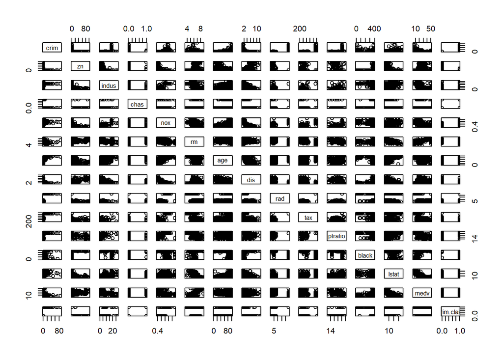

```r
pairs(data)
```

```r
detach(data)
```

http://rpubs.com/Mannypac12/217844